# case_study_RT_accuracy

2023-06-16

## Experiment design

Describe the design of the experiment in your own words: By employing a brief exposure paradigm, this study looks at adaptation to difficult-to-understand speech by manipulating the form in each condition (speech in noise vs foreign-accented speech) and measuring accuracy and RT performance on the task.

## Data cleaning

### 1. Examine RT distribution

Examine the distribution of RT (subjMean_BlockRT) across subjects. Does it make sense?

It reflects the data and some extreme participant mean RTs. For example, participant “7c22ded74c03d60a95d8b0cd59e2a3cc” has a mean RT of 62092.667 for the practice block (that’s plotted in the histogram) and also another mean RT of 16956.333 for the main block (also observed in the plot). I would say that because it includes outliers from the data, it makes sense.

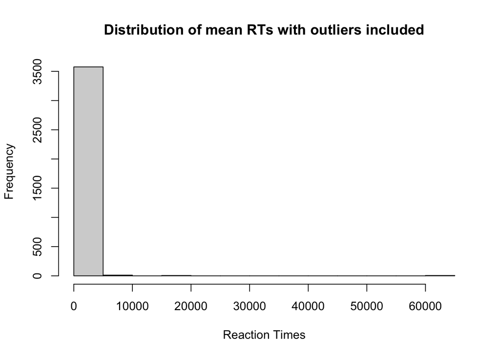

## 2. Data exclusion

Describe the procedure you take to exclude outliers (subjects, trials, etc.).

### Exclusion by subject

Describe your exclusion criteria based on a subject’s performance.

e.g., We want to identify and remove subjects who consistently registered slow response times because they did not perform the task faithfully (e.g., multi-tasking) or because their computer equipment did not provide reliable recording of RTs over the web.

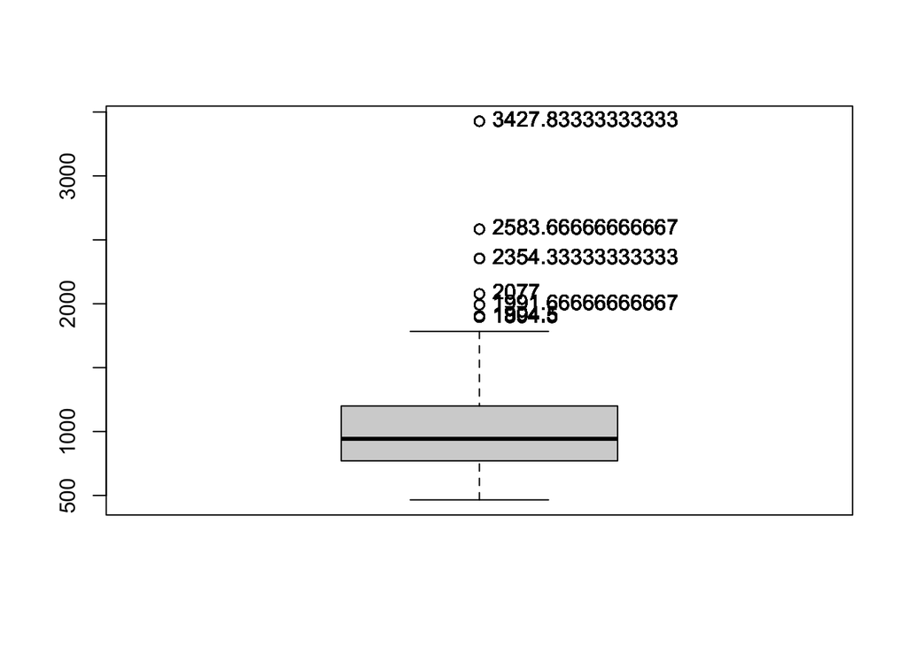

[output not shown]

```
##     Min Lower_Quartile Median Upper_Quartile      Max Outliers
## 1 465.5       770.8333 943.25           1200 1783.667       NA
```

```
##                          Condition subjMean_BlockRT.Mean
## 1          Control (native accent)              1339.168
## 2 Mandarin-accented English (same)              1678.620
##   subjMean_BlockRT.Median subjMean_BlockRT.SD subjMean_BlockRT.Outliers
## 1                1107.000             685.344                  3020.000
## 2                1273.250            3637.288                  3322.667
```

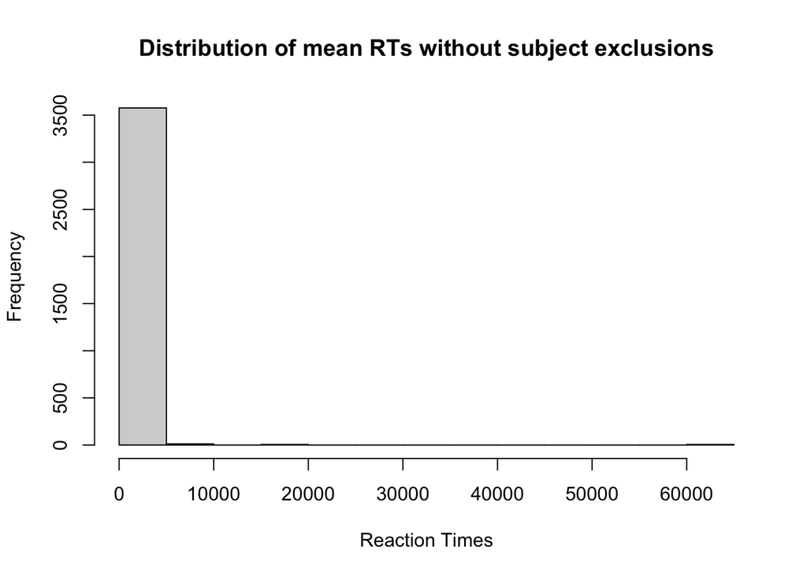

### Exclusion by trial with extreme RTs

The second step of outlier removal was to exclude trials with atypical RTs. Describe your exclusion criteria by trial and do a second round of exclusion.

1. We will exclude trials with RTs that are less than 200ms or greater than 8000ms for each trial.
2. Then, we will exlude trials with RTs that are greater than 3 standard deviations from the participant’s mean RT. (Xie et al., 2018)

Q: Did trial-wise outlier exclusion disproportionately affect any experimental Conditions?

Now that we’ve excluded extreme subject and trial outliers, we can look at the practice and baseline data to assess our high-level predictions about how participants should perform on this web-based task.

1. **One data pattern that we expect to find is that performance (both RTs and accuracy) in the practice and baseline blocks is comparable across experimental conditions.** We expect this because these blocks of the experiment were identical across conditions (i.e., native-accented stimuli presented in the clear).
   - … *if performance in the **practice block** differs substantially across conditions*, we would need to consider whether the subjects in each condition were sampled from the same underlying population (e.g., did we run all conditions at approximately the sme time of day?).
   - … *if performance in the **baseline block** differs substantially across conditions*, we would need to consider whether exposure to different types of speech during the main block of the experiment induced overall differences in task performance (in which case the baseline block doesn’t provide a reliable condition-independent “baseline” for normalization purposes).
2. **A second data pattern that we expect to find is evidence of improvement (adaptation) over the course of the task.** One way this would manifest is faster RTs and increased accuracy in the post-experiment baseline block, relative to the practice phase.

## Summary of exclusion criteria:

- Participant-level exclusions:
  - Identify participants, who across conditions, demonstrate substantially different performance in practice blocks.
  - Identify participants, who across conditions, demonstrate substantially different performance in baseline blocks.
- Trial-level exclusions:
  - RTs and error rates greater than 3SD from the mean.

We applied the same exclusion criteria across all RT and error analyses.

## Normalize experimental RTs relative to baseline

Now that we’ve completed all trial-wise RT exclusions, we can calculate *normalized* RTs that take into account each subject’s baseline speed on this task. For this procedure, we adjust the RTs on each trial by subtracting out the corresponding subject’s mean RT during the baseline phase. We refer to the resulting measure as *adjusted RTs*.

```r
# calculate each subject's mean Baseline RT
# and subtract that value from experimental RTs
dat_out2 %<>%
  group_by(WorkerId) %>%
  mutate(
    # calculate subject-wise mean RTs during baseline block
    meanBaselineRT = mean(RT[PartOfExp == "baseline"]),

    # calculate normalized RTs
    AdjustedRT = RT - meanBaselineRT,

    # calculate subject-wise mean Adjusted RT across Blocks 1-4
    meanAdjustedRT = mean(AdjustedRT[PartOfExp == "main"])
  )
```

Now we want to check the distribution of adjuted RTs to make sure it seems reasonable, given our expectations about task performance.

Note that we expect baseline RTs to be faster on average than RTs during the experimental block, regardless of exposure condition. We expect this for two reasons. First, the baseline task occurred at the end of the experiment, after participants had adapted to the task. Second, *all* participants heard native accented speech during the baseline phase; hence, there was no need for accent adaptation during this phase.

# Modeling strategy

## Variable coding

[output not shown]

# Experiment 1: Adaptation to Mandarin-accented English

## Exp1 Response Times

Visualize the changes of RTs across blocks by condition.

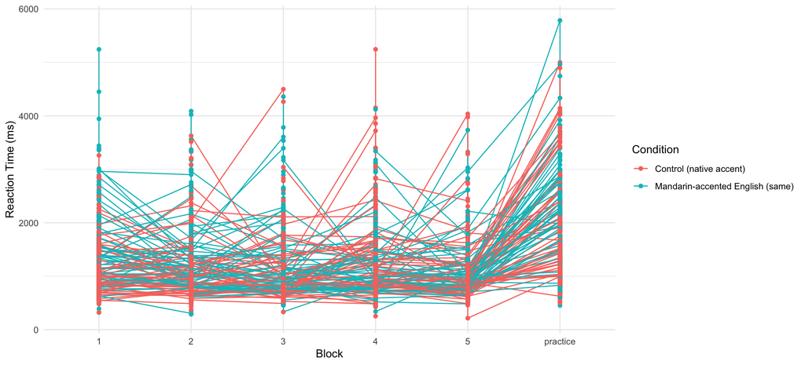

Average RTs by exposure condition in Experiment 1.

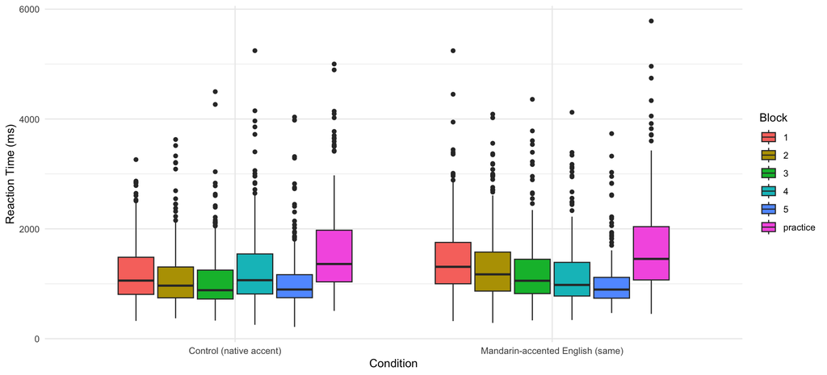

Average RTs by exposure condition in Experiment 1.

#### Exposure

Describe your fixed effects and random effects. Describe how each variable is coded. + Fixed effects: BaselineRTs + Random effects: Block and Condition

```r
# Model specification:
# by-block analysis of RTs during EXPOSURE

head(dat_out2, n=20)
```

```
## # A tibble: 20 × 16
## # Groups:   WorkerId [4]
##    WorkerId         PartOfExp Block Condition Trial Error    RT subjMean_BlockRT
##    <chr>            <chr>     <chr> <chr>     <int> <int> <int>            <dbl>
##  1 8c8d72c6b278ed3… practice  prac… Mandarin…     1     0  3395            1593.
##  2 8c8d72c6b278ed3… practice  prac… Mandarin…     2     0  1745            1593.
##  3 8c8d72c6b278ed3… practice  prac… Mandarin…     3     0  1247            1593.
##  4 8c8d72c6b278ed3… practice  prac… Mandarin…     4     0   908            1593.
##  5 8c8d72c6b278ed3… practice  prac… Mandarin…     5     0  1133            1593.
##  6 8c8d72c6b278ed3… practice  prac… Mandarin…     6     0  1132            1593.
##  7 14781165e2e57c8… practice  prac… Mandarin…     1     1  3917            3323.
##  8 14781165e2e57c8… practice  prac… Mandarin…     3     0  2614            3323.
##  9 14781165e2e57c8… practice  prac… Mandarin…     4     0  3824            3323.
## 10 14781165e2e57c8… practice  prac… Mandarin…     5     0  2322            3323.
## 11 14781165e2e57c8… practice  prac… Mandarin…     6     0  1946            3323.
## 12 436b7651edcd15b… practice  prac… Mandarin…     1     0  3085            1921.
## 13 436b7651edcd15b… practice  prac… Mandarin…     3     0  1438            1921.
## 14 436b7651edcd15b… practice  prac… Mandarin…     4     0  1360            1921.
## 15 436b7651edcd15b… practice  prac… Mandarin…     5     0   628            1921.
## 16 436b7651edcd15b… practice  prac… Mandarin…     6     0   988            1921.
## 17 365b2742b68b830… practice  prac… Mandarin…     1     0  3183            1877
## 18 365b2742b68b830… practice  prac… Mandarin…     2     0  2555            1877
## 19 365b2742b68b830… practice  prac… Mandarin…     3     0  1550            1877
## 20 365b2742b68b830… practice  prac… Mandarin…     4     0  1626            1877
## # ℹ 8 more variables: BaselineRT <dbl>, BaselineRT_raw <dbl>, mean_RT <dbl>,
## #   sd_RT <dbl>, upper_threshold <dbl>, meanBaselineRT <dbl>, AdjustedRT <dbl>,
## #   meanAdjustedRT <dbl>
```

#### Test

```r
# Model specification:
mod = lmerTest::lmer(RT~ BaselineRT + (Block|Condition), data = dat_out2)
# by-block analysis of RTs during TEST

# Jasmin: here in order to see the output of the model, we need to present the results (lmerTest may be a better package than lme4 for this purpose as it gives you the p value directly)
summary(mod)
```

```
## Linear mixed model fit by REML. t-tests use Satterthwaite's method [
## lmerModLmerTest]
## Formula: RT ~ BaselineRT + (Block | Condition)
##    Data: dat_out2
##
## REML criterion at convergence: 54307.5
##
## Scaled residuals:
##     Min      1Q  Median      3Q     Max
## -3.1781 -0.5388 -0.2029  0.3176  6.2329
##
## Random effects:
##  Groups    Name          Variance Std.Dev. Corr
##  Condition (Intercept)    25810   160.7
##            Block2         10236   101.2    -0.75
##            Block3         34443   185.6    -0.78  1.00
##            Block4         46042   214.6    -0.99  0.66  0.69
##            Block5        104103   322.6    -0.86  0.98  0.99  0.79
##            Blockpractice 101934   319.3     0.31 -0.86 -0.84 -0.19 -0.75
##  Residual                341546   584.4
## Number of obs: 3485, groups:  Condition, 2
##
## Fixed effects:
##              Estimate Std. Error        df t value Pr(>|t|)
## (Intercept)  681.3202    26.7004  947.4233   25.52   <2e-16 ***
## BaselineRT     0.5139     0.0220 3479.0224   23.36   <2e-16 ***
## ---
## Signif. codes:  0 '***' 0.001 '**' 0.01 '*' 0.05 '.' 0.1 ' ' 1
##
## Correlation of Fixed Effects:
##            (Intr)
## BaselineRT -0.886
## optimizer (nloptwrap) convergence code: 0 (OK)
## boundary (singular) fit: see help('isSingular')
```